# File Thu Nov 14 24, 16:31:38

## File

**File name:** C:/Users/Paige Ryan/Downloads/RNAseq_subsample.csv  
**Format:** Comma-separated values

## Data

**Data instances:** 121  
**Features:** gene_11439, gene_3840, gene_18582, gene_4880, gene_9955, gene_4455, gene_8743, gene_502, gene_12253, gene_6912, gene_8774, gene_5252, gene_17908, gene_13635, gene_1310, gene_14512, gene_1092, gene_16628, gene_3325, gene_7318, gene_7179, gene_7894, gene_1583, gene_8335, gene_12707, gene_10126, gene_13589, gene_18991, gene_3672, gene_3069, gene_1356, gene_20246, gene_13853, gene_16387, gene_12818, gene_10464, gene_2985, gene_8444, gene_2143, gene_5207, gene_17605, gene_13508, gene_700, gene_5794, gene_17244, gene_7542, gene_10036, gene_213, gene_13839, gene_13424, gene_5143, gene_4357, gene_19995, gene_18381, gene_4051, gene_15353, gene_3277, gene_8095, gene_18540, gene_16071, gene_8514, gene_14128, gene_20189, gene_7873, gene_1221, gene_16681, gene_13370, gene_10961, gene_11181, gene_12974, gene_8297, gene_17554, gene_18084, gene_5336, gene_4577, gene_16058, gene_16448, gene_8744, gene_16624, gene_15646, gene_264, gene_17786, gene_12670, gene_19600, gene_16297, gene_13100, ... (total: 4107 features)

# k-Means Fri Nov 15 24, 17:06:37

**Number of clusters:** 5  
**Optimization:** initialize with KMeans++, 1 re-runs limited to 10000 steps

## Data

**Data instances:** 121  
**Features:** gene_11439, gene_3840, gene_18582, gene_4880, gene_9955, gene_4455, gene_8743, gene_502, gene_12253, gene_6912, gene_8774, gene_5252, gene_17908, gene_13635, gene_1310, gene_14512, gene_1092, gene_16628, gene_3325, gene_7318, gene_7179, gene_7894, gene_1583, gene_8335, gene_12707, gene_10126, gene_13589, gene_18991, gene_3672, gene_3069, gene_1356, gene_20246, gene_13853, gene_16387, gene_12818, gene_10464, gene_2985, gene_8444, gene_2143, gene_5207, gene_17605, gene_13508, gene_700, gene_5794, gene_17244, gene_7542, gene_10036, gene_213, gene_13839, gene_13424, gene_5143, gene_4357, gene_19995, gene_18381, gene_4051, gene_15353, gene_3277, gene_8095, gene_18540, gene_16071, gene_8514, gene_14128, gene_20189, gene_7873, gene_1221, gene_16681, gene_13370, gene_10961, gene_11181, gene_12974, gene_8297, gene_17554, gene_18084, gene_5336, gene_4577, gene_16058, gene_16448, gene_8744, gene_16624, gene_15646, gene_264, gene_17786, gene_12670, gene_19600, gene_16297, gene_13100, ... (total: 4107 features)

## Silhouette scores for different numbers of clusters

| 2 | 0.070 |
| --- | --- |
| 3 | 0.117 |
| 4 | 0.116 |
| 5 | 0.135 |
| 6 | 0.141 |
| 7 | 0.131 |
| 8 | 0.109 |

# Scatter Plot Fri Nov 15 24, 17:06:55

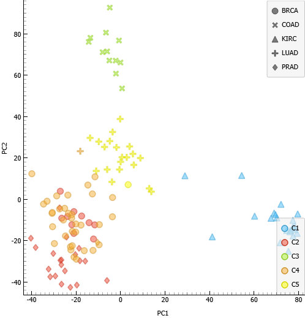

**Color**: Cluster, **Shape**: Class

# Hierarchical Clustering Fri Nov 15 24, 17:39:07

**Linkage:** Single  
**Annotation:** Class  
**Pruning:** 7 levels  
**Selection:** top 5 clusters

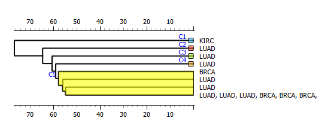

# Scatter Plot Fri Nov 15 24, 17:45:32

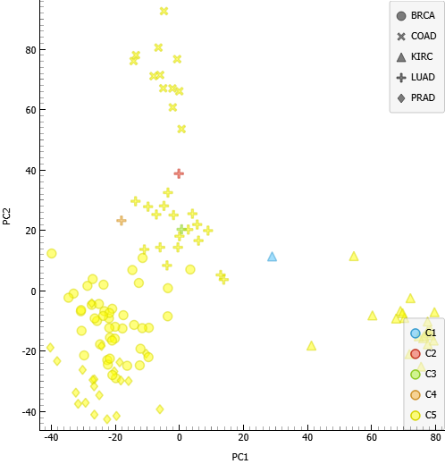

**Color**: Cluster, **Shape**: Class

# Hierarchical Clustering Fri Nov 15 24, 17:46:13

**Linkage:** Complete  
**Annotation:** Class  
**Pruning:** 7 levels  
**Selection:** top 5 clusters

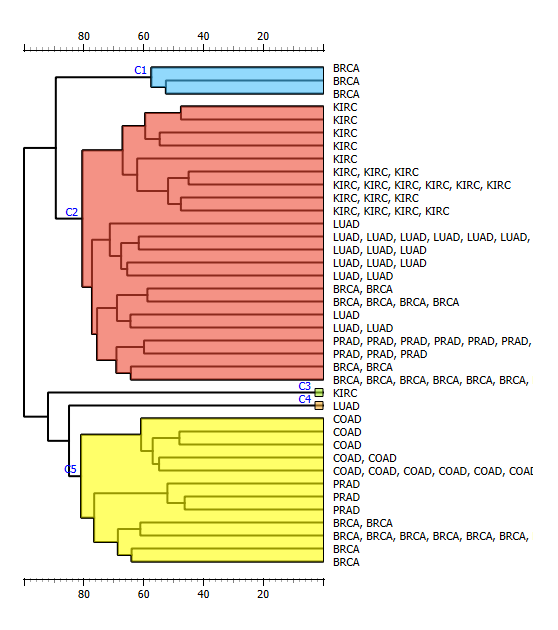

# Scatter Plot Fri Nov 15 24, 17:47:05

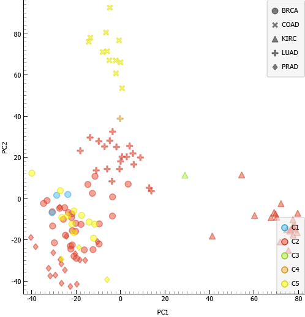

**Color**: Cluster, **Shape**: Class

# Hierarchical Clustering Fri Nov 15 24, 17:48:56

**Linkage:** Ward  
**Annotation:** Class  
**Pruning:** 7 levels  
**Selection:** top 5 clusters

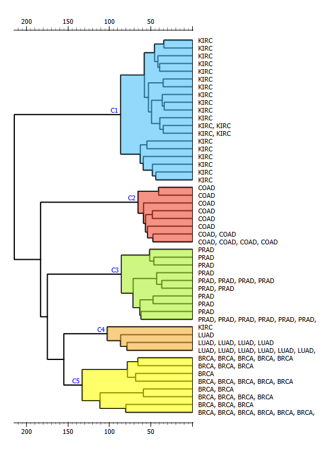

# Scatter Plot Fri Nov 15 24, 17:49:36

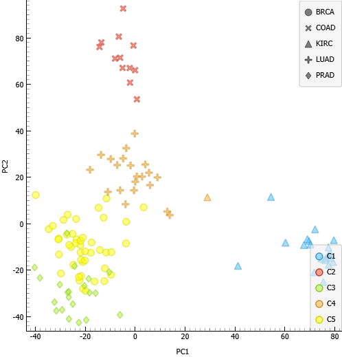

**Color**: Cluster, **Shape**: Class

# Scatter Plot Fri Nov 15 24, 17:58:36

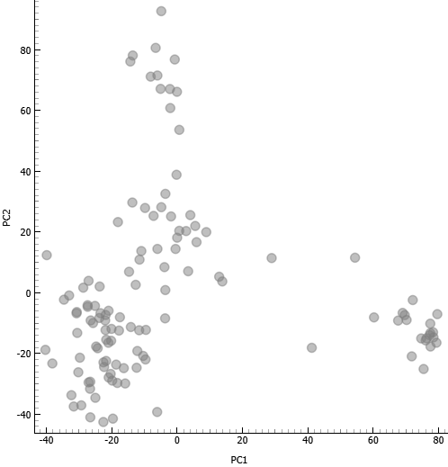

# Scatter Plot Fri Nov 15 24, 18:00:20

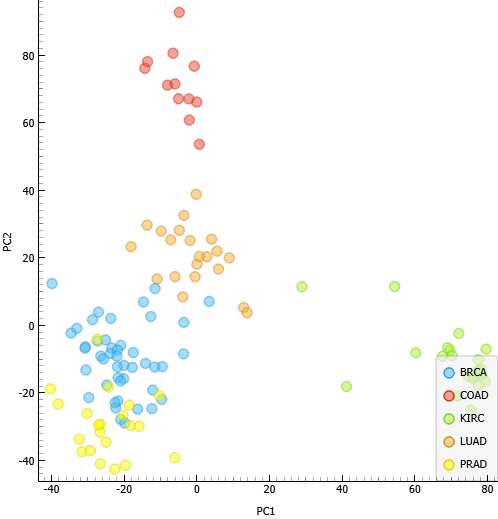

**Color**: Class

# Data Table Fri Nov 15 24, 18:32:31

**Data instances:** 4013  
**Features:** 2  
**Meta attributes:** 1

|  | Feature name | PC1 0.165537 | PC2 0.11868 |
| --- | --- | --- | --- |
| 402 | gene_16342 | 0.111456 | 0.0108778 |
| 1943 | gene_16169 | 0.109773 | -0.0288698 |
| 970 | gene_16392 | 0.106082 | -0.0271898 |
| 878 | gene_16259 | 0.0891868 | -0.0113901 |
| 1250 | gene_7649 | 0.0858068 | 0.0135709 |
| 1708 | gene_18 | 0.0855426 | -0.0238658 |
| 2572 | gene_3921 | 0.0850924 | 0.0604762 |
| 2548 | gene_13818 | 0.0839071 | -0.0215963 |
| 2758 | gene_10950 | 0.0832813 | -0.0150838 |
| 717 | gene_4442 | 0.0823289 | -0.0376992 |
| 171 | gene_11713 | 0.0794184 | -0.00766387 |
| 1428 | gene_16118 | 0.0794014 | -0.0342305 |
| 898 | gene_18676 | 0.0785516 | -0.014105 |
| 2776 | gene_14818 | 0.0766899 | 0.0447949 |
| 2014 | gene_3458 | 0.0755412 | 0.0631996 |
| 2064 | gene_15736 | 0.0739333 | -0.0204953 |
| 817 | gene_13493 | 0.071028 | -0.0284733 |
| 802 | gene_18636 | 0.07061 | 0.0711347 |
| 901 | gene_12977 | 0.070516 | -0.0522501 |
| 1115 | gene_5021 | 0.070105 | -0.0396147 |
| 3414 | gene_13998 | 0.0692122 | 0.0732716 |
| 3022 | gene_19160 | 0.06808 | -0.0187477 |
| 2339 | gene_3453 | 0.0665312 | -0.0162635 |
| 248 | gene_5040 | 0.0662614 | -0.0185532 |
| 3743 | gene_13217 | 0.0650594 | -0.0212568 |
| 1125 | gene_16173 | 0.0650527 | -0.0152633 |
| 221 | gene_11474 | 0.0607751 | 0.0145546 |
| 2003 | gene_16397 | 0.0602262 | -0.00528761 |
| 3659 | gene_12061 | 0.0602243 | -0.011934 |
| 668 | gene_6370 | 0.0597375 | 0.0303625 |

[output cut: 71 more lines]

# t-SNE Fri Nov 15 24, 18:38:35

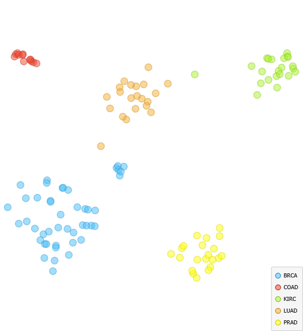

**Color**: Class